# Assignment 1 - Chapter 1-7 Summary LK

Lynnstacy Kegeshi

2024-10-27

This is a summary of Chapter 1-7 of the book **R for Data Science**. We shall be using be data set *Purchase Prediction* to perform our analysis based on the content from Chapter 1 - 7.

We shall be using the following libraries

```r
library(tidyverse)
```

# Chapter 1

The chapter focuses on ggplot2, part of the tidyverse collection of R packages.To get started on this, we shall load our dataset to R Studio and visualize it.

```r
purchaseprediction<-read.csv("Purchase Prediction.csv")
head(purchaseprediction)
```

```
##   CUSTOMER_ID ProductChoice MembershipPoints ModeOfPayment ResidentCity
## 1           1             2                6   MoneyWallet      Madurai
## 2           2             3                2    CreditCard      Kolkata
## 3           3             2                4   MoneyWallet   Vijayawada
## 4           4             3                2   MoneyWallet       Meerut
## 5           5             2                6   MoneyWallet      Madurai
## 6           6             3                6     DebitCard      Kolkata
##   PurchaseTenure Channel IncomeClass CustomerPropensity CustomerAge
## 1              4  Online           4             Medium          55
## 2              4  Online           7           VeryHigh          75
## 3             10  Online           5            Unknown          34
## 4              6  Online           4                Low          26
## 5              3  Online           7           VeryHigh          38
## 6              3  Online           4               High          71
##   MartialStatus LastPurchaseDuration
## 1             0                    4
## 2             0                   15
## 3             0                   15
## 4             0                    6
## 5             1                    6
## 6             0                   10
```

A scatter plot is a chart type that is normally used to observe and visually display the relationship between variables. In this case, we used it to explore the relationship between customer age and last purchase duration. We also incorporated the channel variable to gain insights into the mode of shopping and its distribution. This approach helps us understand how age affects purchasing behavior, providing a clearer picture of customer engagement over time.

By adding facets based on customer propensity, we can further break down the data and see how different customer segments behave, making it easier to identify patterns and trends in their purchasing habits.

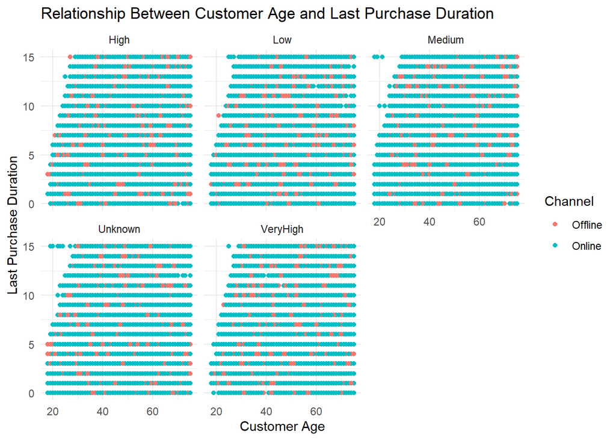

```r
ggplot(data = purchaseprediction, mapping = aes(x = CustomerAge, y = LastPurchaseDuration)) +
  geom_point(aes(colour = Channel)) +
  labs(title = "Relationship Between Customer Age and Last Purchase Duration",
       x = "Customer Age",
       y = "Last Purchase Duration") +
  theme_minimal() +
  facet_wrap(~ CustomerPropensity)
```

We also created a bar graph. By plotting the count of purchases for each ModeOfPayment, we can quickly identify which payment methods are most popular among customers and understand their preferences better.

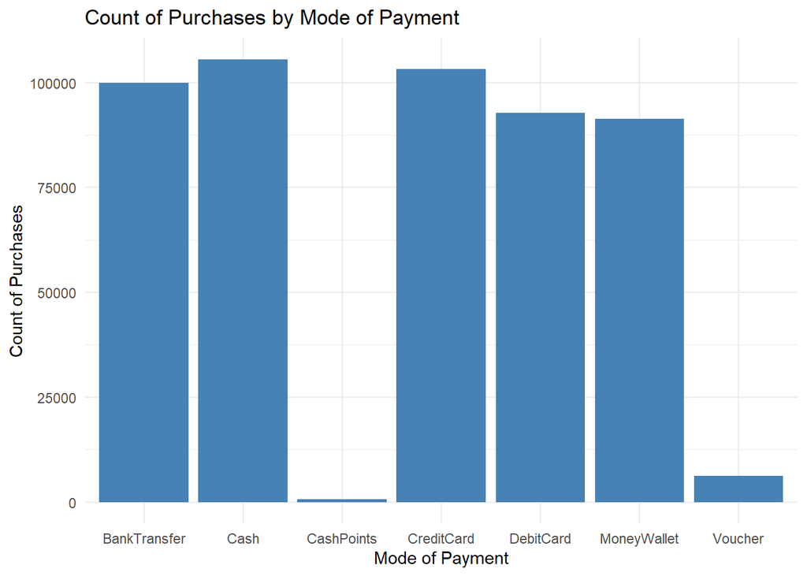

```r
# Create a bar graph of counts
ggplot(data = purchaseprediction, aes(x = ModeOfPayment)) +
  geom_bar(fill = "steelblue") +
  labs(title = "Count of Purchases by Mode of Payment",
       x = "Mode of Payment",
       y = "Count of Purchases") +
  theme_minimal()
```